# COVID-19 data analysis

December 15, 2020

## Introduction

## Coronavirus pandemic (COVID-19)

The project aims to set up the *infrastructure* required to fetch, analyze and publish data COVID-19 data from Our World in Data

Course modules:

1. Overview
2. Statistics
3. Data engineering
4. Data visualization

## 0. Overview

## 1. Statistics

## Statistics

### The dataset

The main dataset obtained from the source has been processed to ease the work with statistical model. Each country has been enriched with data included in an Excel file provided by the professors.

- Identify and define data types
- Simplify the naming of categorical variables
- Set factors and levels (ordinal categories as well)
- Variable `population` from the Excel file is dropped as it is outdated.
- Ensure robust matching joining datasets by assigning country ISO codes to the Excel data.
- Merge datasets

## Statistics

### EDA

*Exploratory data analysis* has been made to understand the nature of the variables as well as the reliability of their values.

- Dropping variables
- Presence of missing values
- Aggregating and summarizing the variables
- Series aggregations

## Statistics

### Variables selection

Discussion to ensure reliability of the data we work with has lead to drop some variables.

- All *weekly* aggregated data from source has been dropped.
- Variables relatively scaled to population *per thousand*. Source dataset provides wider range of variables weighed *per million*.
- `World` and `International` are redundant observations and has been removed to avoid them altering the distribution at a country level.

## Statistics

### Peak into data

|  | iso_code | location | date | total_cases | new_cases | new_cases_smoothed | total_deaths | new_deaths | new_deaths_smoothed | total_cases_per_million | new_cases_per_million | new_cases_smoothed_per_million | total_deaths_per_million | new_deaths_per_million | new_deaths_smoothed_per_million | reproduction_rate | icu_patients | icu_patients_per_million | hosp_patients | hosp_patients_per_million | weekly_icu_admissions | weekly_icu_admissions_per_million | weekly_hosp_admissions | weekly_hosp_admissions_per_million | total_tests | new_tests | total_tests_per_thousand | new_tests_per_thousand | new_tests_smoothed | … |
| --- | --- | --- | --- | --- | --- | --- | --- | --- | --- | --- | --- | --- | --- | --- | --- | --- | --- | --- | --- | --- | --- | --- | --- | --- | --- | --- | --- | --- | --- | --- |
| 1 | ABW | Aruba | 2020-03-13 | 2 | 2 |  |  | 0 |  | 18.733 | 18.733 |  |  | 0 |  |  |  |  |  |  |  |  |  |  |  |  |  |  |  | … |
| 2 | ABW | Aruba | 2020-03-19 |  |  | 0.286 |  |  | 0 |  |  | 2.676 |  |  | 0 |  |  |  |  |  |  |  |  |  |  |  |  |  |  | … |
| 3 | ABW | Aruba | 2020-03-20 | 4 | 2 | 0.286 |  | 0 | 0 | 37.465 | 18.733 | 2.676 |  | 0 | 0 |  |  |  |  |  |  |  |  |  |  |  |  |  |  | … |
| 4 | ABW | Aruba | 2020-03-21 |  |  | 0.286 |  |  | 0 |  |  | 2.676 |  |  | 0 |  |  |  |  |  |  |  |  |  |  |  |  |  |  | … |
| 5 | ABW | Aruba | 2020-03-22 |  |  | 0.286 |  |  | 0 |  |  | 2.676 |  |  | 0 |  |  |  |  |  |  |  |  |  |  |  |  |  |  | … |
| 6 | ABW | Aruba | 2020-03-23 |  |  | 0.286 |  |  | 0 |  |  | 2.676 |  |  | 0 |  |  |  |  |  |  |  |  |  |  |  |  |  |  | … |

## Statistics

### Comparing groups (1)

- For each country, we construct a new variable called `rate`:

```r
data = df0 %>%
  group_by(location) %>%
  mutate(
    new_cases = replace_na(new_cases, 0),
    acc_cases = cumsum(new_cases),
    active_cases = lag(acc_cases) - lag(acc_cases, 15)
  ) %>%
  mutate(
    rate = new_cases/active_cases
  ) %>%
  select(location, date, rate)
```

## Statistics

### Comparing groups (2)

- We only keep observations from Germany and France, and from April to October:

```r
data = data %>%
  mutate(month = lubridate::month(date)) %>%
  filter(location %in% c('Germany', 'France'),
         lubridate::year(date) == 2020, 4 <= month, month <= 10) %>%
  mutate(month = factor(lubridate::month(date), labels = month.abb[4:10]))
```

- To detect differences between countries, we decide to do a two-sample t-test in each month:

```r
dttest = data %>%
  group_by(month) %>%
  nest() %>%
  mutate(
    t_test = map(data, ~t.test(rate~location, data=.x)),
    map_df(t_test, broom::tidy))
```

## Statistics

### Comparing groups (3)

- To visualize the comparison between countries, we try three different approaches.

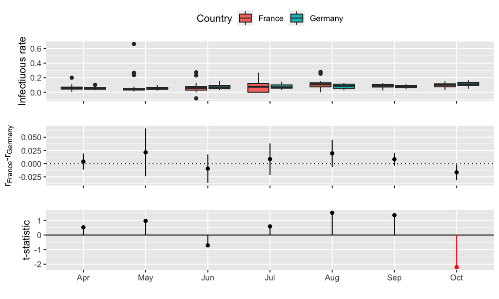

## 2. Data Engineering

## Data Engineering

### Diagram of the pipeline

[figure not shown]

## Data engineering

### Dashboard

[interactive chart not shown]

Further detail on module *3. Data visualization*

## SLIDE EXAMPLES

## Slide with subtitle and common markdown sytntax

### Subtitle

### Title3

#### Title4

- Bullet 1
- Bullet 2

> Quoted content
- Quoted bullet

Highlighting a *word* and another **word** and word

Custom color

## Slide with Plot

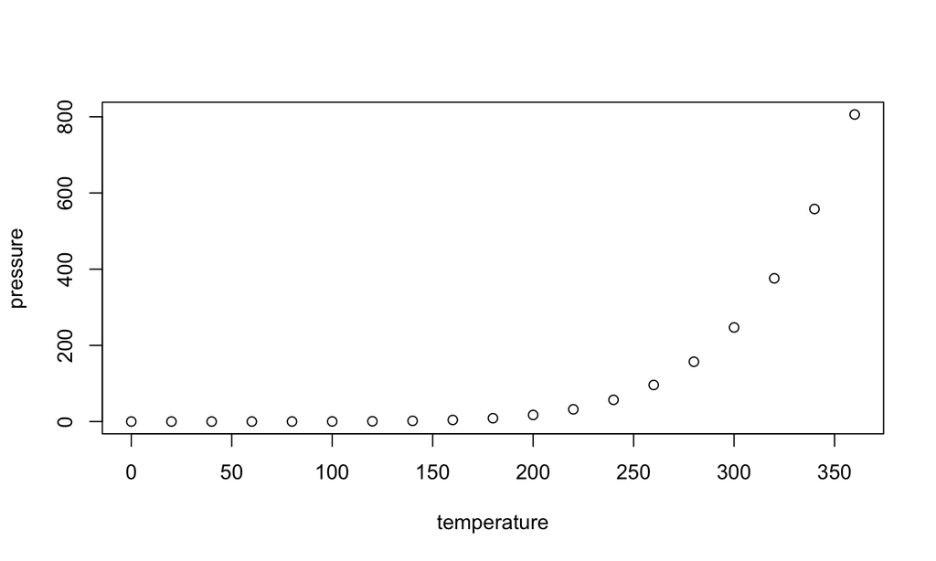

## Slide with Plot Centered

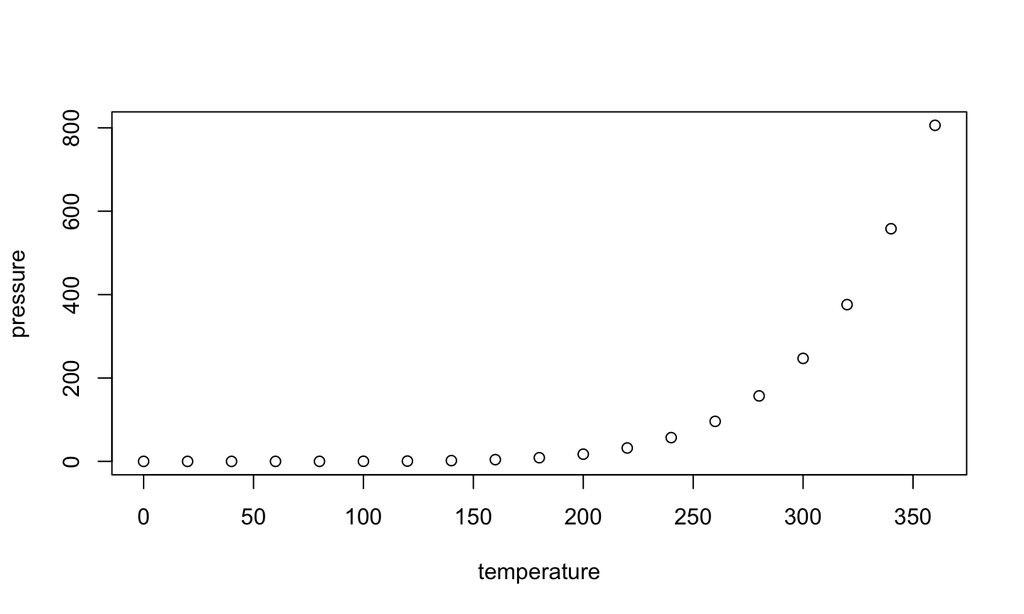

## Slide with Table

| Sepal.Length | Sepal.Width | Petal.Length | Petal.Width | Species |
| --- | --- | --- | --- | --- |
| 5.1 | 3.5 | 1.4 | 0.2 | setosa |
| 4.9 | 3.0 | 1.4 | 0.2 | setosa |
| 4.7 | 3.2 | 1.3 | 0.2 | setosa |
| 4.6 | 3.1 | 1.5 | 0.2 | setosa |
| 5.0 | 3.6 | 1.4 | 0.2 | setosa |
| 5.4 | 3.9 | 1.7 | 0.4 | setosa |

## Slide with datatable

|  | Sepal.Length | Sepal.Width | Petal.Length | Petal.Width | Species |
| --- | --- | --- | --- | --- | --- |
| 1 | 5.1 | 3.5 | 1.4 | 0.2 | setosa |
| 2 | 4.9 | 3 | 1.4 | 0.2 | setosa |
| 3 | 4.7 | 3.2 | 1.3 | 0.2 | setosa |
| 4 | 4.6 | 3.1 | 1.5 | 0.2 | setosa |
| 5 | 5 | 3.6 | 1.4 | 0.2 | setosa |
| 6 | 5.4 | 3.9 | 1.7 | 0.4 | setosa |
| 7 | 4.6 | 3.4 | 1.4 | 0.3 | setosa |
| 8 | 5 | 3.4 | 1.5 | 0.2 | setosa |
| 9 | 4.4 | 2.9 | 1.4 | 0.2 | setosa |
| 10 | 4.9 | 3.1 | 1.5 | 0.1 | setosa |

[output cut: 140 more lines]

## Center Text Vertically

Some text here

## Center Some Text Horizontally

This is not centered

This text is

## Center All Text Horizontally

This text should be centered.

This line as well

## Two Column

[figure not shown]

- Bullet A
- Bullet B
- Bullet C

## Two Column

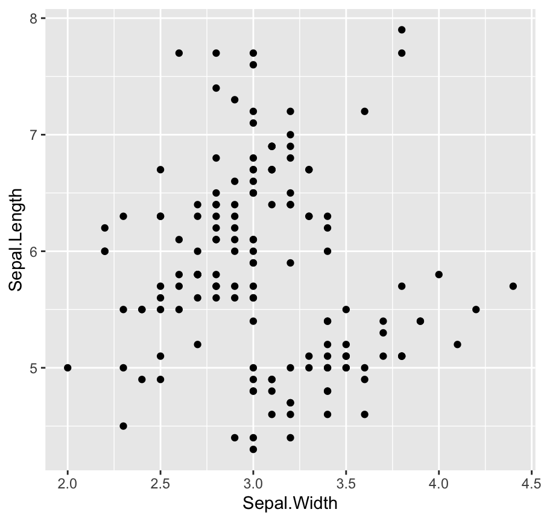

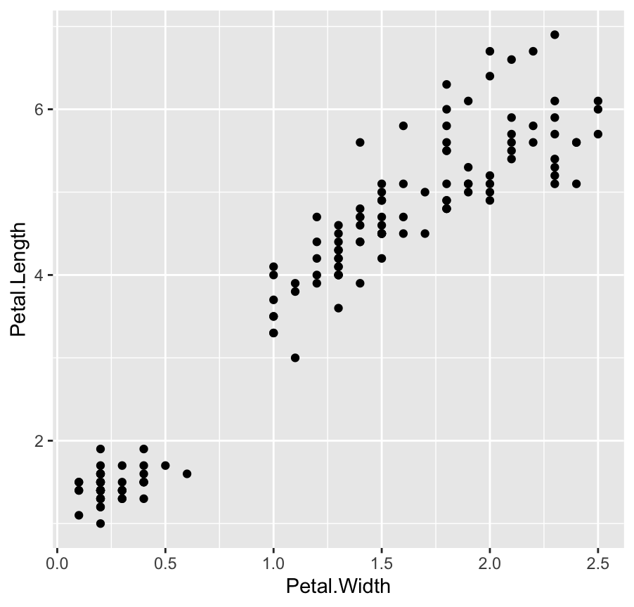